[output not shown]

**Summary:** The CenSoc-DMF-WW2-Army-Enlistment File (N = 1,541,899) links the full-count 1940 Census to the Social Security Death Master File (DMF) and the National Archives’ public release of the United States World War II Army Enlistment Records, circa 1938-1946. Records were linked using the standard variant of the ABE method developed by Abramitzky, Boustan, and Eriksson (2012, 2014, 2017). Variables ending in ’_dmf’ are from the DMF, and those ending in ’_enlistment’ are from the Army Enlistment file. To merge 1940 Census data with this data set, researchers can obtain a copy of the 1940 Census from IPUMS-USA and link on the individual-level, unique identifier HISTID variable.

**serial_number**

**Label**: Army Serial Number

**Description**: serial_number is an assigned number.

**yob**

**Label**: Year of Birth

**Description**: yob reports a person’s year of birth, as recorded in the Social Security Death Master File.

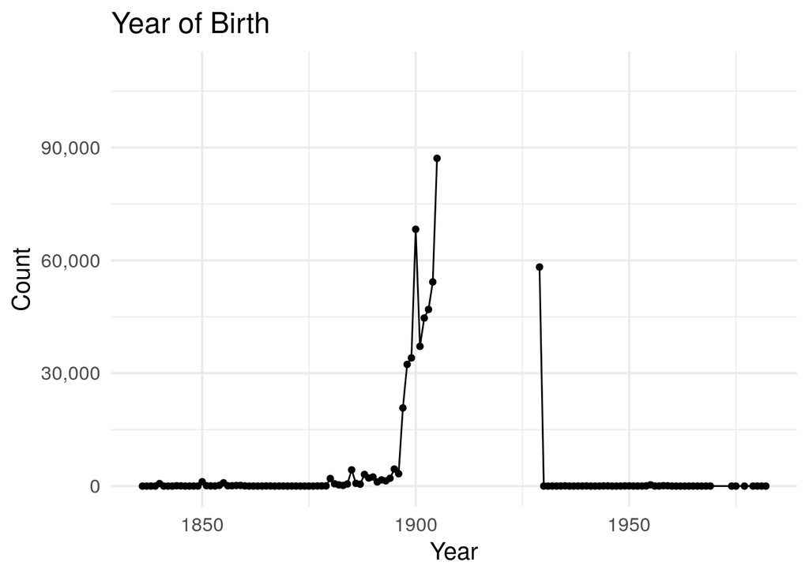

**fname**

**Label:** First Name

**Description:** fname, utilized ABE cleaning method.

**mname**

**Label**: Middle Name

**Description**: mname reports a person’s middle name, utilized ABE cleaning method.

**lname**

**Label**: Last Name

**Description**: lname reports a persons last name cleaned, utilized ABE cleaning method.

**sex**

**Label**: Sex

**Description**: sex reports a person’s sex, as recorded in the Social Security Death Master File.

**date_of_enlistment_ddmmyyyy**

**Label:** Date of Enlistment

**Description**: date_of_enlistment_ddmmyyyy reports a person’s date of enlistment in dd-mm-yyyy format, as reported in the World War II Army Enlistment Records.

```
## [1] "00"
```

```
## [1] "99"
```

```
## # A tibble: 101 × 2
##     year_of_birth      n
##     <chr>          <int>
##   1 00             75666
##   2 01             37455
##   3 02             44819
##   4 03             47044
##   5 04             54527
##   6 05             87980
##   7 06            115443
##   8 07            139574
##   9 08            152448
##  10 09            164656
##  11 10            192693
##  12 11            200464
```

[output cut: 89 more lines]

```
## [1] "00"
```

```
## [1] "T"
```

```
## # A tibble: 101 × 2
##     date_of_enlistment_yy       n
##     <chr>                   <int>
##   1 00                      12480
##   2 01                        993
##   3 02                       3143
##   4 03                        691
##   5 04                       1089
##   6 05                       1208
##   7 06                        294
##   8 07                        156
##   9 08                         73
##  10 09                        394
##  11 10                        211
##  12 11                        390
```

[output cut: 89 more lines]

```
## [1] 202288
```

```
## # A tibble: 7,145 × 2
##    date_enlistment_recode      n
##    <date>                  <int>
##  1 NA                     213886
##  2 1940-09-16              51922
##  3 1940-10-15              35730
##  4 1940-11-25              27318
##  5 1941-02-10              22139
##  6 1941-02-24              20796
##  7 1942-10-30              20649
##  8 1942-11-04              20177
##  9 1942-12-15              20004
## 10 1942-10-27              19986
## # … with 7,135 more rows
```

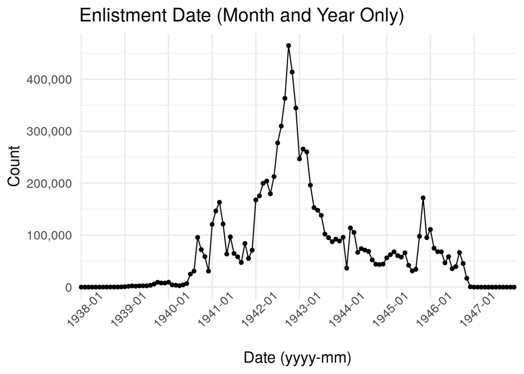

**place_of_birth**

**Label**: Place of Birth

**Description**: place_of_birth reports a person’s place of birth at time of enlistment, as reported in the World War II Army Enlistment Records.

For a complete list of codes, please see: https://aad.archives.gov/aad/popup-codelist.jsp?cl_id=2079&dt=893&c_id=24982

**residence_state**

**Label**: State of residence

**Description**: residence_state is a variable that reports a person’s state of residence at time of enlistment, as reported in the World War II Army Enlistment Records. This variable is only available for enlistees residing in the US.

For a complete list of codes, please see: https://aad.archives.gov/aad/popup-codelist.jsp?cl_id=2057&dt=893&c_id=24998

**residence_county**

**Label**: County of residence

**Description**: residence_county is a numeric variable that reports a person’s county of residence at time of enlistment, as reported in the World War II Army Enlistment Records. This variable is only available for enlistees residing in the US.

For a complete list of codes, please see: https://aad.archives.gov/aad/popup-codelist.jsp?cl_id=2057&dt=893&c_id=24998

**place_of_enlistment**

**Label**: Place of enlistment

**Description**: place_of_enlistment_enlistment is a numeric variable that reports where an person enlisted, as reported in the World War II Army Enlistment Records.

For a complete list of codes, please see: https://aad.archives.gov/aad/popup-codelist.jsp?cl_id=4123&dt=893&c_id=24997

**education**

**Label**: Education

**Description**: education is a numeric variable that reports an individual’s educational attainment at time of enlistment, as reported in the World War II Army Enlistment Records. For a complete list of codes, please see: https://usa.ipums.org/usa-action/variables/EDUC#codes_section

**grade_code**

**Label**: Army grade ((alphanumeric code)rank)

**Description**: grade_code is a string variable that records a person’s grade (rank), as reported in the World War II Army Enlistment Records.

| grade_code | label | n | freq % |
| --- | --- | --- | --- |
| 1 | Master Sergeant | 26283 | 0.264% |
| 2 | First Sergeant | 11421 | 0.115% |
| 3 | Technical Sergeant | 24471 | 0.246% |
| 4 | Staff Sergeant | 48140 | 0.484% |
| 5 | Sergeant | 71338 | 0.717% |
| 6 | Corporal | 89783 | 0.902% |
| 7 | Private First Class | 258778 | 2.6% |
| 8 | Private | 8215100 | 82.5% |
| 9 | Aviation Cadet | 77836 | 0.782% |
| NA | Technician 3d Grade | 377082 | 3.79% |
| NA | Technician 4th Grade | 377082 | 3.79% |
| NA | Technician 5th Grade | 377082 | 3.79% |

```
## # A tibble: 12 × 4
##    grade_code label                      n `freq %`
##         <int> <chr>                  <int> <chr>
##  1          1 Master Sergeant        26283 0.264%
##  2          2 First Sergeant         11421 0.115%
##  3          3 Technical Sergeant     24471 0.246%
##  4          4 Staff Sergeant         48140 0.484%
##  5          5 Sergeant               71338 0.717%
##  6          6 Corporal               89783 0.902%
##  7          7 Private First Class   258778 2.6%
##  8          8 Private              8215100 82.5%
##  9          9 Aviation Cadet         77836 0.782%
## 10         NA Technician 3d Grade   377082 3.79%
## 11         NA Technician 4th Grade  377082 3.79%
## 12         NA Technician 5th Grade  377082 3.79%
```

Code list also is available at: https://aad.archives.gov/aad/popup-codelist.jsp?cl_id=2072&dt=893&c_id=24999

**branch_code**

**Label**: Army branch (alphanumeric code)

**Description**: branch_code is a numeric variable that records the army branch in which the enlistee served, as reported in the World War II Army Enlistment Records.

**term_of_enlistment**

**Label**: Term of enlistment

**Description**: term_of_enlistment_enlistment is a numeric variable that reports the length of a person’s enlistment or their department of enlistment, as reported in the World War II Army Enlistment Records.

Codes also available at: https://aad.archives.gov/aad/popup-codelist.jsp?cl_id=2076&dt=893&c_id=24979

**race**

**Label**: Race

**Description**: race is a string variable that reports an individual’s race, as reported in the World War II Army Enlistment Records.

Codes also available at: https://aad.archives.gov/aad/popup-codelist.jsp?cl_id=2059&dt=893&c_id=24984

**citizenship**

**Label**: Citizenship

**Description**: citizenship is a string variable that reports an individual’s citizenship, as reported in the World War II Army Enlistment Records. 1 indicates the individual was a US citizen, 0 indicates a noncitizen.

Codes also available at: https://aad.archives.gov/aad/popup-codelist.jsp?cl_id=2059&dt=893&c_id=24984

**civillian_occupation**

**Label**: civilian occupation

**Description**: civ_occupation is a string variable that reports a person’s occupation at time of enlistment, as reported in the World War II Army Enlistment Records.

For complete codes, please see: https://aad.archives.gov/aad/popup-codelist.jsp?cl_id=3323&dt=893&c_id=24986

**marital_status**

**Label**: marital status

**Description**: marital_status is a string variable that reports a person’s marital status at time of enlistment, as reported in the World War II Army Enlistment Records.

| marital_status | label | n | freq % |
| --- | --- | --- | --- |
| 1 | Single, with dependents | 2048974 | 22.300 |
| 3 | Separated, with dependents | 157700 | 1.710 |
| 4 | Divorced, with dependents | 215371 | 2.340 |
| 5 | Widower or widow, with dependents | 68436 | 0.744 |
| 6 | Single, without dependents | 6471628 | 70.300 |
| NA | NA | 238123 | 2.590 |

Codes also available at: https://aad.archives.gov/aad/popup-codelist.jsp?cl_id=2081&dt=893&c_id=25001

**height**

**Label**: Height

**Description**: height is a numeric variable that reports a person’s height in inches at time of enlistment, as reported in the World War II Army Enlistment Records.

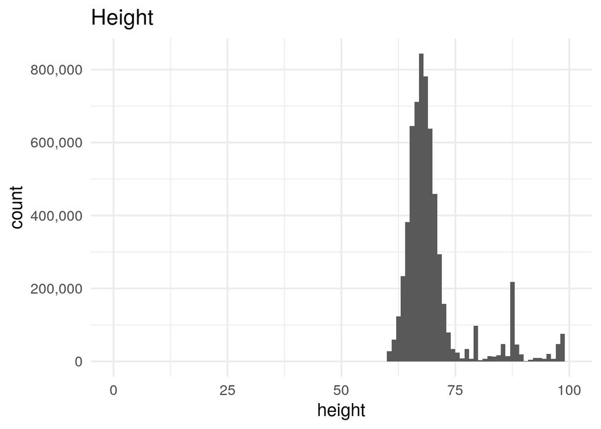

**weight_or_AGCT_enlistment**

**Label**: Weight (pounds) at enlistment or AGCT score

**Description**: weight_or_AGCT_enlistment is a numeric variable that reports a person’s weight in pounds at time of enlistment or their Army General Classification Test (AGCT) score, as reported in the World War II Army Enlistment Records.

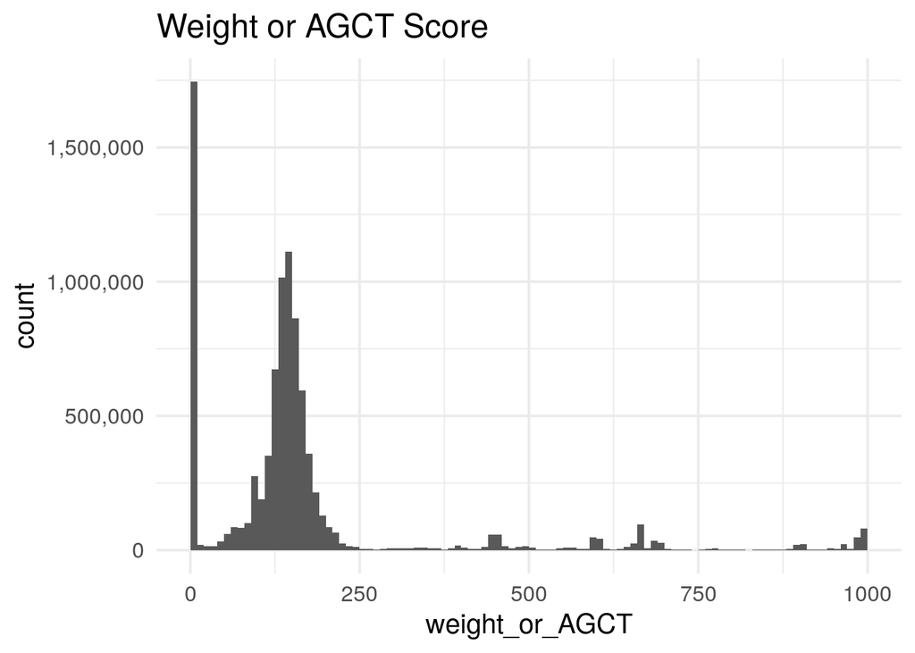

**component_enlistment**

**Label**: Army Component

**Description**: component_enlistment is a numeric variable that records the component of the army in which an individual served, as recorded in the World War II Army Enlistment Records.

Codes also available at: https://aad.archives.gov/aad/popup-codelist.jsp?cl_id=2078&dt=929&c_id=25014

**source**

**Label**: Source of army personnel

**Description**: source is a string variable that reports the source of the enlisted person, as reported in the World War II Army Enlistment Records.

Codes also available at: https://aad.archives.gov/aad/popup-codelist.jsp?cl_id=2077&dt=893&c_id=24981

[^1]: Last updated: 25 April, 2023